# HW6

2022-05-22

## Q1

```r
data<- read_csv("data/Pokemon.csv")%>%clean_names()
data <- data %>% filter((type_1 == "Bug" | type_1 == "Fire" |
                           type_1 == "Grass" | type_1 == "Normal" |
                           type_1 == "Water" | type_1 == "Psychic"))

data$type_1 <- as.factor(data$type_1)
data$legendary <- as.factor(data$legendary)
data$generation <- as.factor(data$generation)



split = initial_split(data, prob = .8,strata = type_1)
poke_train = training(split)
poke_test = testing(split)
folds = vfold_cv(poke_train, v = 5, strata = type_1)


poke_recipe = recipe(type_1 ~ legendary + generation + sp_atk + attack + speed + defense + hp + sp_def, data = poke_train) %>%
  step_dummy(c("legendary", "generation")) %>%
  step_normalize(all_predictors())
```

## Q2

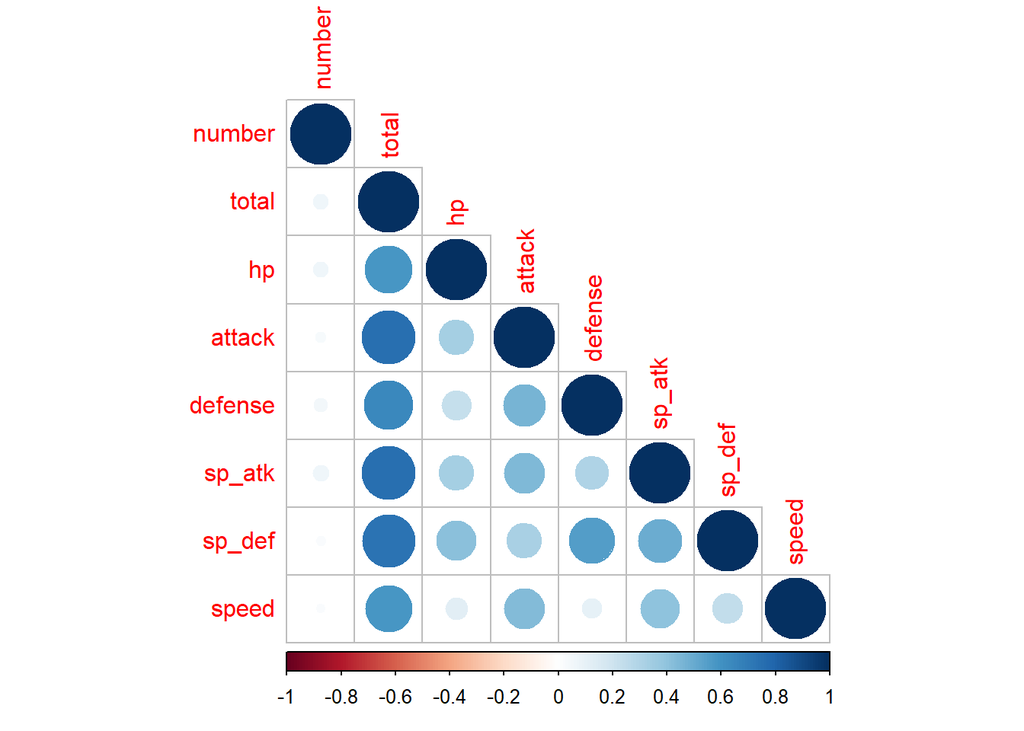

```r
data %>%
  select(is.numeric) %>%
  cor() %>%
  corrplot(type = "lower")
```

We can find that most variable are correlated to each other, for example, there is a positive relation between attack and speed and sp_def with defense. Which make sense for me, strong Pokemon will tend to have stat which is positive related.

## Q3

```r
poke_model = decision_tree(cost_complexity = tune()) %>% #set decision tree model with cost complexity tuned
  set_engine("rpart") %>% #use r part engine
  set_mode("classification") #set mode to classification

tree_workflow = workflow() %>% #create new workflow
  add_recipe(poke_recipe) %>% #add pokemon recipe
  add_model(poke_model) #add decision tree model

grid <- grid_regular(cost_complexity(range = c(-3, -1)), levels = 10)
```

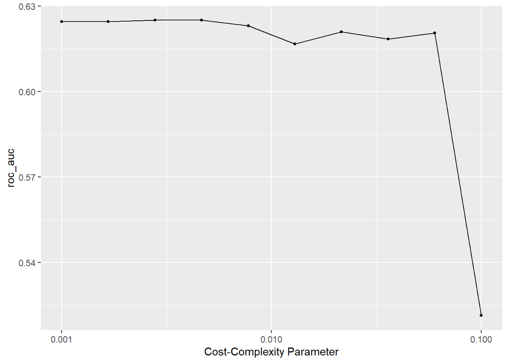

```r
tree_tune <- tune_grid(
  tree_workflow,
  resamples = folds,
  grid = grid,
  metrics = metric_set(roc_auc))

autoplot(tree_tune)
```

we can tell that it will reach a peak and then decrease sharply, and A single decision tree performs better with a smaller cost-complexity penalty.